# Data Analysis and Lab

Lab 2: R Markdown & Cherry Blossom Race Example

Suhwan Bong

2023-09-11

## 1. R Markdown

R Markdown provides an unified authoring framework for data analysis, combining your code, its results, and your prose commentary. R Markdown documents are fully **reproducible** and support dozens of output formats, like PDFs, Word files, slideshows, and more.

R Markdown files are designed to be used in three ways:

1. For communicating to decision makers, who want to focus on the conclusions, not the code behind the analysis.
2. For collaborating with other data analyst (including future you!), who are interested in both your conclusions, and how you reached them (i.e. the code).
3. As an environment in which to do data analysis, as a modern day lab notebook where you can capture not only what you did, but also what you were thinking.

### Reproducible analysis with R Markdown

The concept of literate programming was introduced by Knuth decades ago. His advice was:

“Instead of imagining that our main task is to instruct a computer what to do, let us concentrate rather on explaining to human beings what we want a computer to do.”

Central to this prescription is the idea that the relevant documentation for the code-which is understandable not just to the programmer, but to other human beings as well-occurs alongside the code itself. In data analysis, this is manifest as the need to have three kinds of things in one document: the code, the results of that code, and the written analysis. We belong to a growing group of people who find the `rmarkdown` and `knitr` packages to be an environment that is ideally suited to support a reproducible analysis workflow.

Watch this Prezi presentation by Andrew Bray: https://prezi.com/rtmytpb6iwsw/reproducible-20/

### Getting help

R Markdown integrates a number of R packages, including the `rmarkdown` and `knitr`, and external tools. This means that help is, by-and-large, not available through `?`. Instead, as you use R Markdown in the future, keep these resources close to hand:

- R Markdown Cheat Sheet: *Help > Cheatsheets > R Markdown Cheat Sheet*,
- R Markdown Reference Guide: *Help > Cheatsheets > R Markdown Reference Guide*.

Both cheatsheets are also available at http://rstudio.com/cheatsheets.

### R Markdown basics

We begin by creating a new R Markdown document. Within RStudio, a new template R Markdown file can be generated by selecting R Markdown from the New File option on the File menu. This generates the dialog box. The default output format is HTML, but other options (PDF or Microsoft Word) are available. The formatted output can be generated and displayed by clicking the `Knit` HTML button in RStudio, or by using the commands in the following code block, which can also be used when running R without the benefit of RStudio.

```r
library(rmarkdown)
render("filename.Rmd")      # creates filename.html
browseURL("filename.html")
```

When you *knit* the document, R Markdown sends the .Rmd file to knitr, http://yihui.name/knitr/, which executes all of the code chunks and creates a new markdown (.md) document which includes the code and its output. The markdown file generated by knitr is then processed by *pandoc*, http://pandoc.org/, which is responsible for creating the finished file. The advantage of this two step workflow is that you can create a very wide range of output formats, as you’ll learn about in R markdown formats.

### Text formatting with Markdown

Prose in `.Rmd` files is written in Markdown, a lightweight set of conventions for formatting plain text files. Markdown is designed to be easy to read and easy to write. It is also very easy to learn. The guide below shows how to use Pandoc’s Markdown, a slightly extended version of Markdown that R Markdown understands.

```
Text formatting
------------------------------------------------------------

*italic*  or _italic_
**bold**   __bold__
`code`
superscript^2^ and subscript~2~

Headings
------------------------------------------------------------

# 1st Level Header

## 2nd Level Header

### 3rd Level Header

Lists
------------------------------------------------------------

*   Bulleted list item 1

*   Item 2

    * Item 2a

    * Item 2b

1.  Numbered list item 1

1.  Item 2. The numbers are incremented automatically in the output.

Links and images
------------------------------------------------------------

<http://example.com>

[linked phrase](http://example.com)

![optional caption text](path/to/img.png)

Tables
------------------------------------------------------------

First Header  | Second Header
------------- | -------------
Content Cell  | Content Cell
Content Cell  | Content Cell
```

### Code chunks

To run code inside an R Markdown document, you need to insert a chunk. There are three ways to do so:

1. The keyboard shortcut Cmd/Ctrl + Alt + I
2. The “Insert” button icon in the editor toolbar.
3. By manually typing the chunk delimiters `` ```{r} `` and `` ``` ``.

R code chunks can be used as a means render R output into documents or to simply display code for illustration. Here is a simple R code chunk that will result in both the code and it’s output being included:

````markdown
```{r}
summary(cars)
```
````

To display the output of a code chunk but not the underlying R code, you specify the `echo=FALSE` option:

````markdown
```{r, echo=FALSE}
summary(cars)
```
````

Note that R code chunks can also be used to render plots. To display a plot while omitting the code used to generate the plot you’d do this:

````markdown
```{r, echo=FALSE}
plot(cars)
```
````

To display R code without evaluating it, you specify the `eval=FALSE` chunk option:

````markdown
```{r, eval=FALSE}
summary(cars)
```
````

As seen above, chunk output can be customised with options, arguments supplied to chunk header. A full list of chunk options is available at http://yihui.name/knitr/options/.

### Exercises

1. Create a new R Markdown document and modify the code by inserting `head(cars)` and `plot(cars)`. See modified output and render your file to a PDF document.
2. Create a new R Markdown document. The author should be your name. The exercise is to include a bulleted list of courses you have taken and the semester the course was offered. (Include only three courses you liked the most.) Highlight the semester-year in bold. In the document, include any image, available through a URL, that is of interest to you. Use “`![]()`” command. Render your .Rmd file to an HTML document.

## 2. Cherry Blossom Race Example

In this era of ‘free and ubiquitous data,’ there is tremendous potential in seeking out data to bring insight to a problem we are working on professionally or to a topic of personal interest. For example, we are interested in understanding how people’s physical performance changes as they age. One source of data about this comes from road races. Hundreds of thousands of people participate in road races each year; the race organizers collect information about the runners’ times and often publish individual-level data on the Web. These freely accessible data may provide us with insights to our question about performance and age.

One example of the many annual road races is the Cherry Blossom Ten Mile Run held in Washington D.C. in early April when the cherry trees are typically in bloom. The Cherry Blossom started in 1973 as a training run for elite runners who were planning to compete in the Boston Marathon. It has since grown in popularity and in 2012 nearly 17,000 runners ranging in age from 9 to 89 participated. After each year’s race, the organizers publish the results. These data offer a tremendous resource for learning about the relationship between age and performance.

- **Computational Topics**
  - Use regular expressions to extract and clean messy data from pre-formatted text tables and to create unique identifiers for matching records that belong to the same individual.
  - Employ statistical techniques to identify bad data and to confirm these problems have been corrected.
  - Visualize data that have a large number of observations (~150,000 records).
  - Gain experience with the R formula language for plots and modeling.
  - Fit piecewise linear models using least squares and non-parametric curves using local averaging.
  - Scrape simple Web pages for text content.

## Reading tables of race results into R

Our goal in this section is to transform the raw text tables of race results into data that can be analyzed in R.

```r
m2012 <- read.table("MenTxt/2012.txt", skip = 8)
```

```
## Error in scan(file = file, what = what, sep = sep, quote = quote, dec = dec, : line 1 did not have 12 elements
```

By inspection, we see that a call to read.table() will not properly read the text into a data frame because the information, e.g., place and division, are separated by blanks but blanks also appear in the data values, i.e., blanks also occur where they are not being used as variable separators. Note that we skipped the first 8 lines of the file because these belong to the header of the file.

```r
els = readLines("MenTxt/2012.txt")
els[1:10]
```

```
##  [1] ""
##  [2] "                 Credit Union Cherry Blossom Ten Mile Run"
##  [3] "                 Washington, DC     Sunday, April 1, 2012"
##  [4] ""
##  [5] "                Official Male Results (Sorted By Net Time)"
##  [6] ""
##  [7] "Place Div  /Tot   Num    Name                   Ag Hometown             5 Mile  Time    Pace  "
##  [8] "===== =========== ====== ====================== == ==================== ======= ======= ===== "
##  [9] "    1     1/347        9 Allan Kiprono          22 Kenya                  22:32   45:15  4:32 "
## [10] "    2     2/347       11 Lani Kiplagat          23 Kenya                  22:38   46:28  4:39 "
```

We also read in and display the first 10 rows of the 2011 male results so we have another table to compare with the 2012 table. We find the following:

```r
els2011 = readLines("MenTxt/2011.txt")
els2011[1:10]
```

```
##  [1] ""
##  [2] "                 Credit Union Cherry Blossom Ten Mile Run"
##  [3] "                 Washington, DC     Sunday, April 3, 2011"
##  [4] ""
##  [5] "                           Official Male Results"
##  [6] ""
##  [7] "Place Div  /Tot   Num    Name                   Ag Hometown             5 Mile  Gun Tim Net Tim Pace  "
##  [8] "===== =========== ====== ====================== == ==================== ======= ======= ======= ===== "
##  [9] "    1     1/401        3 Lelisa Desisa          21 Ethiopia                       45:36   45:36  4:34 "
## [10] "    2     2/401       13 Allan Kiprono          21 Kenya                  23:08   45:41   45:41  4:35 "
```

What do we find with this simple inspection?

- Both of the tables have a header.
- The last line of the header is a row of ‘=’ characters, i.e., a separation line.
- There are blanks inserted in the row of ‘=’ characters that mark the start and end of a column of information, e.g., the Pace column occupies 5 spaces.
- The row above the ‘=’ characters gives column names.
- There are two times reported in 2011 (called `Gun Tim` and `Net Tim`) and only one time reported in 2012 (`Time`). The header of the 2012 file tells us that `Time` is net time.

Let’s use the 2012 men’s results as our test case for developing the code to read in all the files. Our first step is to find the row with the equal signs. The rows below it contain the data, the row above it holds the column headers, and the row itself supplies the spacings for the columns. We saw earlier that the ‘=’ characters are in the eighth row of the 2012 table. Since the organization of the tables differs a bit from year to year, we use a programmatic search for the equal signs. We use `grep()` to search through the character strings in `els` for one that begins with, say, 3 equal signs as follows:

```r
eqIndex = grep("^===", els)
eqIndex
```

```
## [1] 8
```

Note that an alternative to regular expressions and the `grep()` function is to use `substr()` to extract the first 3 characters from each row and compare them to the string “===”. That is,

```r
first3 = substr(els, 1, 3)
which(first3 == "===")
```

```
## [1] 8
```

The choice of 3 ‘=’ characters is somewhat arbitrary. We could have used just one as the equal sign does not appear elsewhere in the document. Now that we have located this key row in the table, we extract it and the row above it and discard earlier rows with

```r
spacerRow = els[eqIndex]
headerRow = els[eqIndex - 1]
body = els[ -(1:eqIndex) ]
```

Our next task is to extract the various pieces of information from each string in body, i.e., the content of the table. How might we extract the runner’s age? From inspection, a runner’s age appears in the column labeled `Ag` or `AG` so we first convert the column names to lower case so we need not search separately for `Ag` and `AG`. We use `tolower()` to do this with

```r
headerRow = tolower(headerRow)
ageStart = regexpr("ag", headerRow)
ageStart
```

```
## [1] 49
## attr(,"match.length")
## [1] 2
## attr(,"index.type")
## [1] "chars"
## attr(,"useBytes")
## [1] TRUE
```

The return value from `regexpr()` tells us a match was found in position 49 of the character string. If no match is found, then `regexpr()` returns -1. Now we have the information about the location of runner’s age: it begins in position 49 and ends at the 50th position in each row of the table. We use this information to extract each runner’s age using `substr()` as follows:

```r
age = substr(body, start = ageStart, stop = ageStart + 1)
head(age)
```

```
## [1] "22" "23" "36" "27" "24" "31"
```

```r
summary(as.numeric(age))
```

```
##    Min. 1st Qu.  Median    Mean 3rd Qu.    Max.    NA's
##    9.00   29.00   35.00   37.75   45.00   89.00       1
```

We can extract all of our variables in this manner, but the width of a column might change from one year to the next so we generalize our code to search the row of equal signs for blank spaces and use the position of these to determine the locations of the columns. This approach is better than searching for variable names to find the starting position of the column of values. We find the locations of all of the blanks in the line of ‘=’ characters with

```r
blankLocs = gregexpr(" ", spacerRow)
blankLocs
```

```
## [[1]]
## [1]  6 18 25 48 51 72 80 88 94
## attr(,"match.length")
## [1] 1 1 1 1 1 1 1 1 1
## attr(,"index.type")
## [1] "chars"
## attr(,"useBytes")
## [1] TRUE
```

Here the g in `gregexpr()` stands for “global,” which means that the function searches for multiple matches in the string, not just the first match. Blank spaces are found at the 6th, 18th, 25th, 48th, 51st, etc. positions. In general, we want to write our code so that it does not depend on a variable name starting or ending in a particular column. We can extract all the columns of values using `blankLocs` to determine the start and end positions of the columns. The starting position of a column is one character past a blank and the ending position is one character before a blank. In order to properly handle the first column, we can augment `blankLocs` with 0 so the first column starts one character after 0, i.e.,

```r
searchLocs = c(0, blankLocs[[1]])
```

We can extract all the columns using `substr()` with

```r
Values = mapply(substr, list(body),
                start = searchLocs[ -length(searchLocs)] + 1,
                stop = searchLocs[ -1 ] - 1)
```

We encapsulate the task of finding the starting and ending positions of the columns into a function, which we call `findColLocs()`. In the function, we safeguard against the last character in the row of ‘=’ characters not being a blank, we add an additional element to the end of the vector of locations that is one character more than the length of the string. Our function appears as:

```r
findColLocs = function(spacerRow) {
  spaceLocs = gregexpr(" ", spacerRow)[[1]]
  rowLength = nchar(spacerRow)
  if (substring(spacerRow, rowLength, rowLength) != " ")
    return( c(0, spaceLocs, rowLength + 1))
  else return(c(0, spaceLocs))
}
```

```r
selectCols = function(colNames, headerRow, searchLocs)
{
  sapply(colNames,
         function(name, headerRow, searchLocs)
         {
          startPos = regexpr(name, headerRow)[[1]]
          if (startPos == -1)
            return( c(NA, NA) )
          index = sum(startPos >= searchLocs)
          c(searchLocs[index] + 1, searchLocs[index + 1] - 1)
         },
         headerRow = headerRow, searchLocs = searchLocs )
}
```

Notice that the function is simply a wrapper to a call to sapply(). However, this encapsu- lation makes it easy for us to test our code on individual column names and to extract a subset of columns. Since the column names vary somewhat from year to year, we use only the first few characters that uniquely identify the desired columns, e.g.,

```r
shortColNames = c("name", "home", "ag", "gun", "net", "time")
```

Also, if a file does not have one of the desired variables, then we want the values for that variable to be NA. We can anticipate this situation because we have seen that the 2011 file has gun time and net time, but not time, and the 2012 file has a column labeled time, but no gun or net times.

```r
locCols = selectCols(shortColNames, headerRow, searchLocs)
Values = mapply(substr, list(body), start = locCols[1, ],
                stop = locCols[2, ])
class(Values)
```

```
## [1] "matrix" "array"
```

The results form a matrix of character strings. (We have not yet converted any values such as age to numeric.) We see that the first few rows of the matrix are

```r
colnames(Values) = shortColNames
head(Values)
```

```
##      name                     home                   ag   gun net time
## [1,] "Allan Kiprono         " "Kenya               " "22" NA  NA  "  45:15"
## [2,] "Lani Kiplagat         " "Kenya               " "23" NA  NA  "  46:28"
## [3,] "John Korir            " "Kenya               " "36" NA  NA  "  47:33"
## [4,] "Ian Burrell           " "Tucson AZ           " "27" NA  NA  "  47:34"
## [5,] "Jesse Cherry          " "Blowing Rock NC     " "24" NA  NA  "  47:40"
## [6,] "Ketema Nugusse        " "Ethiopia            " "31" NA  NA  "  47:50"
```

The 2012 table has a column for time and not gun and net times so the gun and net values are NA. We also check the last few lines with

```r
tail(Values)[ , 1:3]
```

```
##         name                     home                   ag
## [7188,] "Dana Brown            " "Randallstown MD     " "41"
## [7189,] "Jurek Grabowski       " "Fairfax VA          " "39"
## [7190,] "Larry Hume            " "Arlington VA        " "56"
## [7191,] "Sean-Patrick Alexander" "Alexandria VA       " "35"
## [7192,] "Joseph White          " "Forestville MD      " "  "
## [7193,] "Lee Jordan            " "Herndon VA          " "48"
```

We wrap up the process of extracting the columns into a function so we can apply it to each year’s data. This function calls our helper functions `findColLocs()` and `selectCols()`. Our function might look like

```r
extractVariables =
  function(file, varNames =c("name", "home", "ag", "gun", "net", "time")){

     # Find the index of the row with =s
    eqIndex = grep("^===", file)

     # Extract the two key rows and the data
    spacerRow = file[eqIndex]
    headerRow = tolower(file[ eqIndex - 1 ])
    body = file[ -(1 : eqIndex) ]

     # Obtain the starting and ending positions of variables
    searchLocs = findColLocs(spacerRow)
    locCols = selectCols(varNames, headerRow, searchLocs)
    Values = mapply(substr, list(body), start = locCols[1, ], stop = locCols[2, ])
    colnames(Values) = varNames
    invisible(Values)
}
```

We are ready to create the data frames for each year, but the `extractVariables()` function expects the file passed to it for the extraction to be a character vector. We first must read the lines of the tables into R. We do this with:

```r
mfilenames = paste("MenTxt/", 1999:2012, ".txt", sep = "")
menFiles = lapply(mfilenames, readLines)
names(menFiles) = 1999:2012

menResMat = lapply(menFiles, extractVariables)
length(menResMat)
```

```
## [1] 14
```

```r
sapply(menResMat, nrow)
```

```
## 1999 2000 2001 2002 2003 2004 2005 2006 2007 2008 2009 2010 2011 2012
## 3190 3016 3621 3723 3946 4156 4324 5235 5274 5905 6649 6909 7011 7193
```

We see that we get reasonable values for the number of rows in our matrices. Our next task is then to convert these character matrices into a format that we can readily analyze. As we do this, we use statistics to check the results and find that additional data cleaning is necessary. This is the topic of the next section.

## Data Cleaning and Reformatting Variables

In this section, we consider how to convert the list of character matrices, menResMat, into an appropriate format for analysis. Currently, the data values are all character, which is not conducive to, e.g., finding the median age of the runners. However, we can easily reformat age into numeric values with the `as.numeric()` function. Do we want to turn the entire matrix into a numeric matrix? Not really. It doesn’t make sense to try to convert the runner’s name into a numeric value. For this reason, we want to create a data frame because it allows our variables to be different types. We have 6 variables: the runner’s name, home town, age, and 3 versions of time. As just mentioned, we want to convert age to a numeric and leave name as character. What about the other variables? We probably want to also keep hometown as character.

We begin with the task of creating the numeric variable age with `as.numeric()`, e.g., for the 2012 males,

```r
age = as.numeric(menResMat[['2012']][ , 'ag'])
head(age)
```

```
## [1] 22 23 36 27 24 31
```

These values look reasonable, but let’s check more thoroughly that our data extraction works as expected by summarizing each year’s ages with

```r
age = sapply(menResMat, function(x) as.numeric(x[ , 'ag']))
```

We received a warning message that our conversion of the character values for age into numeric resulted in NA values, meaning that some of the values do not correspond to numbers. We want to look into the specific cause of these messages, but first we examine `age`. We create side-by-side boxplots of the yearly distribution of the age of the runners to give a quick check on the reasonableness of the values.

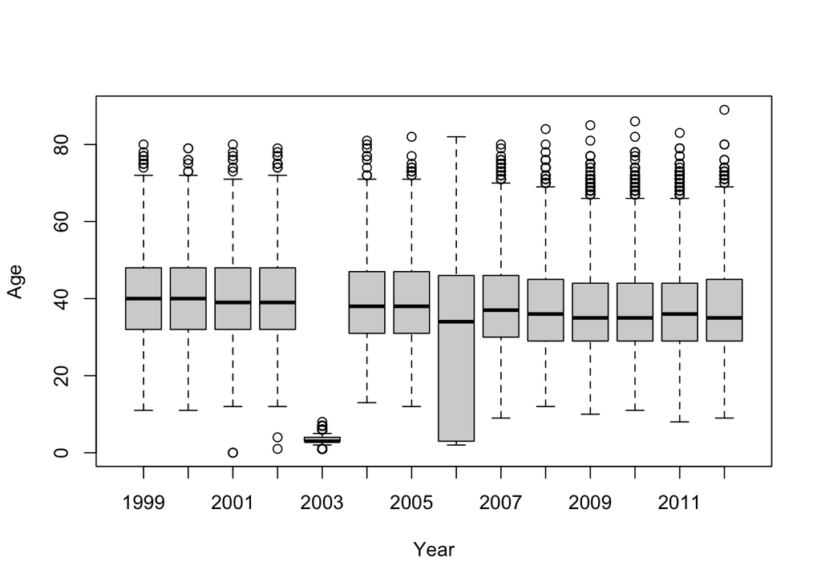

```r
boxplot(age, ylab = "Age", xlab = "Year")
```

Let’s examine the original text for 2003 and 2006:

```r
head(menFiles[['2003']])
```

```
## [1] ""
## [2] "Place Div /Tot  Num    Name                          Ag Hometown            Gun Tim  Net Tim "
## [3] "===== ========= ===== ============================= == =================== =======  ======= "
## [4] "    1    1/1999     6  John Korir                    27  KEN                  46:56#   46:55 "
## [5] "    2    2/1999     1  Reuben Cheruiyot              28  KEN                  47:03#   47:02 "
## [6] "    3    3/1999     8  Gilbert Okari                 24  KEN                  47:07#   47:07 "
```

```r
menFiles[['2006']][2200:2205]
```

```
## [1] " 2192 1263/2892   1475 Matt Curtis            39 Vienna          1:27:08 1:27:40   8:46   "
## [2] " 2193  94/279    1437 Joe McCloskey          59 Columbia        1:27:01 1:27:40   8:46   "
## [3] " 2194 257/590    7062 Donald Hofmann         48 Princeton Junct 1:25:45 1:27:41   8:47   "
## [4] " 2195 1264/2892   7049 Claudio Petruzziello   23 Princeton Jct   1:25:45 1:27:41   8:47   "
## [5] " 2196 339/746    3319 Robert Morrison        40 South Boston    1:23:54 1:27:41   8:47   "
## [6] " 2197 1265/2892   9345 Larry Cooper           32 Arlington       1:26:42 1:27:41   8:47   "
```

We see that in 2003, the age values are shifted to the right one space in comparison to the location of the ‘=’ characters. This means that we are picking up only the digit in the tens place. In 2006, some but not all of the rows have values that are off by one character. We can easily solve both of these problems by including the value in the “blank” space between columns. We can do this by changing the index for the end of each variable when we perform the extraction. That is, we modify the line in `selectCols()` that locates the end of a column to include the blank position, i.e.,

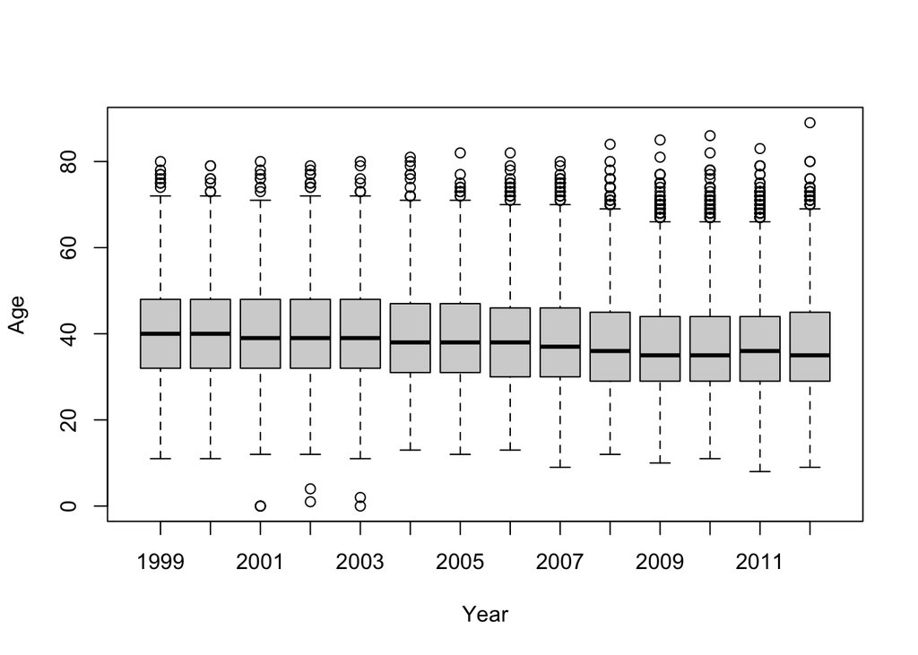

```r
# c(searchLocs[index] + 1, searchLocs[index + 1])
selectCols = function(colNames, headerRow, searchLocs)
{
  sapply(colNames,
         function(name, headerRow, searchLocs)
         {
          startPos = regexpr(name, headerRow)[[1]]
          if (startPos == -1)
            return( c(NA, NA) )
          index = sum(startPos >= searchLocs)
          c(searchLocs[index] + 1, searchLocs[index + 1])
         },
         headerRow = headerRow, searchLocs = searchLocs )
}

mfilenames = paste("MenTxt/", 1999:2012, ".txt", sep = "")
menFiles = lapply(mfilenames, readLines)
names(menFiles) = 1999:2012

menResMat = lapply(menFiles, extractVariables)
age = sapply(menResMat, function(x) as.numeric(x[ , 'ag']))

boxplot(age, ylab = "Age", xlab = "Year")
```

We now turn to the warning messages that occurred when we converted the character strings for age to numeric values. We were given several messages ‘NAs introduced by coercion’. We count the number of NA values in each year with

```r
sapply(age,  function(x) sum(is.na(x)))
```

```
## 1999 2000 2001 2002 2003 2004 2005 2006 2007 2008 2009 2010 2011 2012
##    1    0   60    2    0    0   10    0    3    0    0    4    0    1
```

```r
age2001 = age[["2001"]]
```

Let’s examine the original rows in the file that correspond to an NA in `age2001`. Recall that we dropped the header of the file before extracting the variables so we need to add an offset to the location of the NAs in `age2001` in order to pick out the correct rows in the original table. We find the offset with

```r
grep("^===", menFiles[["2001"]])
```

```
## [1] 5
```

We then find the lines in the original file that have the bad age values with

```r
badAgeIndex = which(is.na(age2001)) + 5
menFiles[["2001"]][ badAgeIndex ]
```

```
##  [1] "             "                  "                              "
##  [3] "                      "         ""
##  [5] "                         "      ""
##  [7] ""                               ""
##  [9] "             "                  "                              "
## [11] "                      "         ""
## [13] "                         "      ""
## [15] ""                               ""
## [17] "             "                  "                              "
## [19] "                      "         ""
## [21] "                         "      ""
## [23] ""                               ""
## [25] ""                               "    "
## [27] "         "                      ""
## [29] "            "                   ""
## [31] ""                               ""
## [33] ""                               "             "
## [35] "                              " "                      "
## [37] ""                               "                         "
## [39] ""                               ""
## [41] ""                               "             "
## [43] "                              " "                      "
## [45] ""                               "                         "
## [47] ""                               ""
## [49] ""                               ""
## [51] ""                               ""
## [53] "             "                  "                              "
## [55] "                      "         ""
## [57] "                         "      ""
## [59] ""                               ""
```

```r
badAgeIndex
```

```
##  [1] 1756 1757 1758 1759 1760 1761 1762 1763 1814 1815 1816 1817 1818 1819 1820
## [16] 1821 1872 1873 1874 1875 1876 1877 1878 1879 1930 1931 1932 1933 1934 1935
## [31] 1936 1937 2538 2539 2540 2541 2542 2543 2544 2545 2546 2897 2898 2899 2900
## [46] 2901 2902 2903 2904 2955 2956 2957 3008 3009 3010 3011 3012 3013 3014 3015
```

These blank lines are scattered throughout the file. We can modify the extraction by checking for blank rows and removing them. The regular expression,

```r
blanks = grep("^[[:blank:]]*$", menFiles[['2001']])
```

locates all rows that are entirely blank. The first argument to grep uses several meta characters to specify the pattern to search for. The ^ is an anchor for denoting the start of the string, the $ anchors to the end of the string, the [[:blank:]] denotes the equivalence class of space and tab characters, and the * indicates that the blank character can appear 0 or more times. All together the pattern ^[[:blank:]]*$ matches a string that contains any number of blanks from start to end, i.e., only blank lines.

Continued inspection uncovers another problem – the minimum values for age in 2001, 2002, and 2003 remain small, i.e., close to 0. That’s clearly not possible! Let’s find which runners have an age under 5 and look at their records in the original table. For 2001, we have

```r
which(age2001 < 5)
```

```
## [1] 1377 3063 3112
```

```r
menFiles[['2001']][ which(age2001 < 5) + 5 ]
```

```
## [1] " 1377  5629 Steve PINKOS           0 Washington DC      1:20:07 1:22:34"
## [2] " 3003  5033 Jeff LAKE              0 Clarksville MD     1:39:26 1:41:22"
## [3] " 3052  5637 Greg RHODE             0 Washington DC      1:37:14 1:42:13"
```

Apparently there are runners with an age entered as 0! Since these are the actual values in the table, we leave the decision as to what to do with these runners for later when we analyze the data. At this point, it appears we have successfully taken care of the creation of the age variable. However, we typically clean the variables simultaneously as an error in one variable often leads to errors in others based on position. As we clean the other variables, we may need to re-examine age to ensure that the values for age remain valid.

```r
charTime = menResMat[['2012']][, 'time']
head(charTime, 5)
```

```
## [1] "  45:15 " "  46:28 " "  47:33 " "  47:34 " "  47:40 "
```

```r
tail(charTime, 5)
```

```
## [1] "2:27:11 " "2:27:20 " "2:27:30 " "2:28:58 " "2:30:59 "
```

We split each character string up into its parts using `strsplit()` with

```r
timePieces = strsplit(charTime, ":")
timePieces[[1]]
```

```
## [1] "  45" "15 "
```

```r
tail(timePieces, 1)
```

```
## [[1]]
## [1] "2"   "30"  "59 "
```

We convert these elements to numeric values and combine them into one value that reports time in minutes with

```r
convertTime <- function(x){
                   if (length(x) == 2) x[1] + x[2]/60
                   else 60*x[1] + x[2] + x[3]/60
}
timePieces = sapply(timePieces, as.numeric)
runTime = sapply(timePieces, convertTime)
```

We check our conversion with

```r
summary(runTime)
```

```
##    Min. 1st Qu.  Median    Mean 3rd Qu.    Max.
##   45.25   77.57   87.47   88.43   97.78  150.98
```

It appears that our time conversion works. We saw earlier that the fastest runner completed the 2012 race in 45 minutes and 15 seconds, which is 45.25 minutes, and the slowest com- pleted it in 2 hours 30 minutes and 59 seconds, which is nearly 151 minutes.

Let’s wrap these conversions into a function to apply to the character matrices in `menResMat` and return a data frame with variables for analysis. We call this function `createDF()`. In addition to the conversion of character strings to numeric, we also create two new variables, `year` and `sex`. To do this, we must have input arguments to tell us which year we are cleaning and whether the results are for men or women. Lastly, we also choose which time variable to include in the data frame from among the 3 available, with a preference for net time. The function appears as

```r
createDF =
function(Res, year, sex)
{
       # Determine which time to use
  useTime = {if( !is.na(Res[1, 'net']) ){Res[ , 'net']}
            else if( !is.na(Res[1, 'gun']) ){Res[ , 'gun']}
            else{Res[ , 'time']}}
  timePieces = strsplit(useTime, ":")
  timePieces = sapply(timePieces, as.numeric)
  runTime = sapply(timePieces, convertTime)
  Results = data.frame(year = rep(year, nrow(Res)),
                       sex = rep(sex, nrow(Res)),
                       name = Res[ , 'name'],
                       home = Res[ , 'home'],
                       age = as.numeric(Res[, 'ag']),
                       runTime = runTime,
                       stringsAsFactors = FALSE)
  invisible(Results)
}
```

We apply our new function, `createDF()`, to all of the male results as follows:

```r
menDF = mapply(createDF, menResMat, year = 1999:2012, sex = rep("M", 14), SIMPLIFY = FALSE)
```

We check the warnings. It is likely that the conversion problems are coming from the conversion of time from a character string into minutes because we have already handled the conversion of age. We can check the number of NA values for `runTime` with

```r
sapply(menDF, function(x) sum(is.na(x$runTime)))
```

```
## 1999 2000 2001 2002 2003 2004 2005 2006 2007 2008 2009 2010 2011 2012
##    0    0   60    0    0    0    0 5232   83    0   72   68    0    0
```

There are a large number of NAs in 2001.

```r
head(menResMat$"2001"[which(is.na(menDF$"2001"$runTime)),])
```

```
##      name                 home ag gun net time
## [1,] " "                  ""   "" ""  ""  NA
## [2,] "                  " ""   "" ""  ""  NA
## [3,] "          "         ""   "" ""  ""  NA
## [4,] ""                   ""   "" ""  ""  NA
## [5,] "             "      ""   "" ""  ""  NA
## [6,] ""                   ""   "" ""  ""  NA
```

Also, there are a large number of NAs in 2007, 2009, and 2010, and it appears that all of the run time values for 2006 are NA. Let’s begin by examining a few of the records in 2007, 2009, and 2010 that have an NA in run time.

```r
head(menResMat$"2010"[which(is.na(menDF$"2010"$runTime)),])
```

```
##      name                      home                    ag    gun
## [1,] "Stephen Tum            " "Kenya                " "24 " "  45:43 "
## [2,] "Lelisa Desisa          " "Ethiopia             " "20 " "  45:44 "
## [3,] "Tilahun Regassa        " "Ethiopia             " "20 " "  45:50 "
## [4,] "John Korir             " "Kenya                " "34 " "  46:05 "
## [5,] "Stephen Muange         " "Kenya                " "28 " "  46:34 "
## [6,] "Gilbert Okari          " "Kenya                " "31 " "  46:39 "
##      net        time
## [1,] "  45:43#" NA
## [2,] "  45:44#" NA
## [3,] "  45:50#" NA
## [4,] "  46:05#" NA
## [5,] "  46:34#" NA
## [6,] "  46:39#" NA
```

We find that these are caused by runners who completed half the race but have no final times and by runners who have a footnote after their time. We can easily modify `createDF()` to eliminate the footnote symbols (# and *) from the times and drop records of runners who do not complete the race. These revisions are

```r
createDF =
function(Res, year, sex)
{
       # Determine which time to use
  useTime = {if( !is.na(Res[1, 'net']) ){Res[ , 'net']}
            else if( !is.na(Res[1, 'gun']) ){Res[ , 'gun']}
            else{Res[ , 'time']}}
       # Remove # and * and blanks from time
  useTime = gsub("[#\\*[:blank:]]", "", useTime)
       # Drop rows with no time
  Res = Res[ useTime != "", ]
  timePieces = strsplit(useTime[ useTime != "" ], ":")

  timePieces = sapply(timePieces, as.numeric)
  runTime = sapply(timePieces, convertTime)
  Results = data.frame(year = rep(year, nrow(Res)),
                       sex = rep(sex, nrow(Res)),
                       name = Res[ , 'name'],
                       home = Res[ , 'home'],
                       age = as.numeric(Res[, 'ag']),
                       runTime = runTime,
                       stringsAsFactors = FALSE)
  invisible(Results)
}
menDF = mapply(createDF, menResMat, year = 1999:2012, sex = rep("M", 14), SIMPLIFY = FALSE)
sapply(menDF, function(x) sum(is.na(x$runTime)))
```

```
## 1999 2000 2001 2002 2003 2004 2005 2006 2007 2008 2009 2010 2011 2012
##    0    0    0    0    0    0    0 5232    0    0    0    0    0    0
```

Let’s see the final problem of 2006.

```r
head(menResMat$"2006"[which(is.na(menDF$"2006"$runTime)),])
```

```
##      name                      home                       ag    gun
## [1,] "Gilbert Okari          " "Kenya             47:24 " "27 " "  47:25#"
## [2,] "Samuel Ndereba         " "Kenya             47:34 " "29 " "  47:35#"
## [3,] "Rueben Kibet Chebii    " "Kenya             47:38 " "23 " "  47:39#"
## [4,] "Kazuo Ietani           " "Japan             47:39 " "28 " "  47:39#"
## [5,] "Wilson Komen           " "Kenya             47:58 " "28 " "  47:58#"
## [6,] "Matt Downin            " "United States     48:42 " "29 " "  48:43#"
##      net                        time
## [1,] "Kenya             47:24 " NA
## [2,] "Kenya             47:34 " NA
## [3,] "Kenya             47:38 " NA
## [4,] "Japan             47:39 " NA
## [5,] "Kenya             47:58 " NA
## [6,] "United States     48:42 " NA
```

We will use gun time for 2006.

```r
createDF =
function(Res, year, sex)
{
       # Determine which time to use
  useTime = {if( !is.na(Res[1, 'net']) ){Res[ , 'net']}
            else if( !is.na(Res[1, 'gun']) ){Res[ , 'gun']}
            else{Res[ , 'time']}}
  if (year == 2006){useTime = Res[ , 'gun']}
       # Remove # and * and blanks from time
  useTime = gsub("[#\\*[:blank:]]", "", useTime)
       # Drop rows with no time
  Res = Res[ useTime != "", ]
  timePieces = strsplit(useTime[ useTime != "" ], ":")

  timePieces = sapply(timePieces, as.numeric)
  runTime = sapply(timePieces, convertTime)
  Results = data.frame(year = rep(year, nrow(Res)),
                       sex = rep(sex, nrow(Res)),
                       name = Res[ , 'name'],
                       home = Res[ , 'home'],
                       age = as.numeric(Res[, 'ag']),
                       runTime = runTime,
                       stringsAsFactors = FALSE)
  invisible(Results)
}
menDF = mapply(createDF, menResMat, year = 1999:2012, sex = rep("M", 14), SIMPLIFY = FALSE)
sapply(menDF, function(x) sum(is.na(x$runTime)))
```

```
## 1999 2000 2001 2002 2003 2004 2005 2006 2007 2008 2009 2010 2011 2012
##    0    0    0    0    0    0    0    0    0    0    0    0    0    0
```

At last, we combine the race results for all years and men into one data frame using the `do.call()` function to call `rbind()` with the list of data frames as input. That is,

```r
cbMen = do.call(rbind, menDF)
save(cbMen, file = "cbMen.rda")

# rbind(menDF[[1]], menDF[[2]], menDF[[3]], menDF[[4]],
#       menDF[[5]], menDF[[6]], menDF[[7]], menDF[[8]],
#       menDF[[9]], menDF[[10]], menDF[[11]], menDF[[12]],
#       menDF[[13]], menDF[[14]])
```

The `do.call()` function is very convenient when we have the individual arguments to a function as elements of a list. We check the dimension of our amalgamated data frame with

```r
dim(cbMen)
```

```
## [1] 70070     6
```

```r
head(cbMen)
```

```
##        year sex                   name                home age  runTime
## 1999.1 1999   M Worku Bikila           Ethiopia             28 46.98333
## 1999.2 1999   M Lazarus Nyakeraka      Kenya                24 47.01667
## 1999.3 1999   M James Kariuki          Kenya                27 47.05000
## 1999.4 1999   M William Kiptum         Kenya                28 47.11667
## 1999.5 1999   M Joseph Kimani          Kenya                26 47.51667
## 1999.6 1999   M Josphat Machuka        Kenya                25 47.55000
```